# demo: p-value 的意義

Szu-Hsien Ho

2022-05-16

```r
library(tidyverse)
```

### Problem 2. p-value 的意義

考慮二值變數 $x$，我們事先已知：在母體中隨機取樣，有 $97\%$ 的機率，$x$ 取值為 $0$，有 $3\%$ 的機率，$x$ 取值為 $1$。我們也知道：對於相同的 $x$ 取 $N$ 個樣本點，變數 $y$ 的分佈是「$μ = x, σ^2 = 100/N$」的常態分配 $N(x, 100/N)$。  
現在，對於某個未知的 $x$ 取 $N$ 個樣本點，測得 $y = 2.2$。若虛無假設為 $H_0: x = 0$，並設定顯著性水準 (significance level) 為 $\alpha = 0.05$。

(1) 當 $N = 100$, p-value 是多少？你會拒絕 $H_0$ 嗎？

#### Answer:

當 $N = 100$, p-value 為 0.028（雙尾檢定），小於顯著性水準 $\alpha = 0.05$，拒絕 $H_0$。 註：p-value 的意義為：若 $H_0$ 為真，出現量測數值或更極端值的機率。  
本情境中，這個機率小於我們設定的門檻 $\alpha$，代表很不可能出現，根據 Neyman-Pearson 的假設檢定邏輯，我們拒絕虛無假定 $H_0$。

```r
N <- 100
y <- 2.2
var <- 100
mu0 <- 0
mu1 <- 1

z_test <- (y-mu0)/(sqrt(var/N))
p_value <- 2*pnorm(q=z_test, lower.tail=FALSE)
p_value
```

```
## [1] 0.0278069
```

(2) 請簡單解釋統計檢定力的意義。當$N = 100$, 統計檢定力 (power) 是多少？

#### Answer:

統計檢定力的意義是：當 $H_0$ 為假，正確地拒絕虛無虛無假設的機率。 在這裡表示：當未知的 $x$ 真實值為 $1$ 時，拒絕 $H_0: x = 0$ 的機率。  
檢定力 (power) 是$0.17$，所以只有$17\%$的機率「當$x = 1$的時候，拒絕 $x = 0$ 的虛無假定」。  
值得注意的是：雖然上題的 p-value 小於 $\alpha$, 拒絕 $H_0$，但檢定力並不高， 因為樣本數 $N = 100$ 還不夠大。

```r
power_calc <- function(N, alpha=0.05, var=100, mu0=0, mu1=1, h0_true=0.97, h0_false=0.03){
    # left critical value
    crit_L <- qnorm(alpha/2, mu0, sqrt(var/N))
    # right critical value
    crit_R <- qnorm(1-alpha/2, mu0, sqrt(var/N))
    ## pnorm() default: lower.tail = TRUE
    ## check: h0_T = alpha/2
    # h0_T <- pnorm(crit_L, mu0, sqrt(var/N))
    power <- pnorm(crit_L, mu1, sqrt(var/N)) +
        pnorm(crit_R, mu1, sqrt(var/N), lower.tail=FALSE)
    ## power: (correctly) reject H0 given H1 is correct
    ## Prob(H0: True | H0: rejected) = 分子/分母
    ## 分子 = Prob(H0: True & H0: rejected)
    ## 分母 = Prob(H0: True & H0: rejected)+ Prob(H0: False & H0: rejected)
    ## = Prob(H0: rejected | H0: True) * Prob(H0: True) +
    ##   Prob(H0: rejected | H0: False) * Prob(H0: False)
    ## = alpha * Prob(H0: True) + power * Prob(H0: False)

    h0_true_geiven_rejected <- (alpha * h0_true)/(alpha * h0_true + power * h0_false)
    df <-tibble(N, alpha, power, h0_true_geiven_rejected)
}

df <- power_calc(100)
power <- df$power
power
```

```
## [1] 0.170075
```

(3) 請繪製統計檢定力與樣本數 $N$ 的圖形，亦即：power (y-axis) against $N$ (x-axis) 的圖形。

#### Answer:

$N$ 越大 power 越大。在這裡假定樣本數越多，$y$ 的變異數越低 ($y$ 可能是某種平均值，變異數與 $1/N$ 成正比)，所以，若 $H_0$ 為假，樣本數越多，估計值接近母體參數，越容易拒絕 $H_0$，代表 power 愈大。

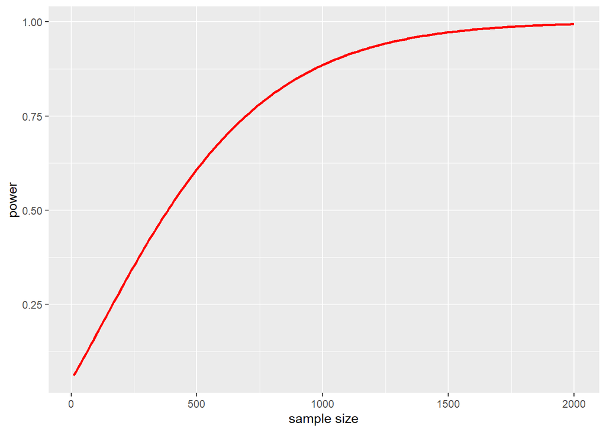

```r
N <- seq(10, 2000, by = 10)
df <- power_calc(N)
ggplot(df, aes(x = N, y = power)) +
    geom_line(color = "red", size = 1) +
    xlab("sample size") +
    ylab("power")
```

(4) 在拒絕 $H_0$ 的情況下 ($H_0$ is rejected)，請分別繪製：  
(i) $\text{Prob}(H_0 \text{ is True } | H_0 \text{ is rejected})$ against $N$ 的圖形。  
(ii) $\text{Prob}(H_0 \text{ is True } | H_0 \text{ is rejected})$ against power 的圖形。

#### Answer:

1. $N$ 越大 $\text{Prob}(H_0 \text{ is True } | H_0 \text{ is rejected})$ 越小。
2. power 越大 $\text{Prob}(H_0 \text{ is True } | H_0 \text{ is rejected})$ 越小。

在本題設定下 $N$ 和 power 成正相關，這兩部分一起解釋。

題目給了如下數值： （為讓後續計算清爽，做了一點縮寫：$\mathbb{P}$ 表示機率，冒號表示 is，$T$ 與 $F$ 分別表示 True 與 False，而 $r$ 表示 rejected）

$\mathbb{P}(H_0: T) = 0.97, \mathbb{P}(H_0: F) = 0.03$,

另外，我們知道

$\alpha = \mathbb{P}(H_0: r | H_0: T), \text{power} = \mathbb{P}(H_0: r | H_0: F)$.

根據貝氏定理：

$$\begin{align*}
\mathbb{P}(H_0: T | H_0: r) & = \frac{\mathbb{P}(H_0: T \;\&\;
H_0: r)}{\mathbb{P}(H_0: r)}
= \frac{\mathbb{P}(H_0: r \;\&\; H_0: T)}{\mathbb{P}(H_0: r
\;\&\; H_0: T) + \mathbb{P}(H_0: r \;\&\; H_0: F)} \\
& = \frac{\mathbb{P}(H_0: r | H_0: T) \cdot \mathbb{P}(H_0: T)}{
\mathbb{P}(H_0: r | H_0: T) \cdot \mathbb{P}(H_0: T) +
\mathbb{P}(H_0: r | H_0: F) \cdot \mathbb{P}(H_0: F)}
= \frac{\alpha \cdot 0.97}{\alpha \cdot 0.97 + \text{power} \cdot 0.03}.
\end{align*}$$

計算結果表明，這種「反機率」(與 $\alpha$ 或 power 的定義前提資訊相反) 確實隨著 power 越大而越小。 因此，當樣本數 $N$ 增加、檢定力 power 上升時， 「若 $H_0$ 被拒，但 $H_0$ 確實為真」的犯錯機率就會下降，也就是說樣本與檢定力的增加可以減少估計錯誤的結果。

但是本題 $\text{Prob}(H_0 \text{ is True}) = 0.97$ 壓倒性地高，$\alpha$ 設定也不夠小，所以當樣本數已經大到 $2000$，power 接近 $1$ 時，這個犯錯機率還是超過 $0.6$ (極限是 $0.05 \times 0.97 / (0.05 \times 0.97 + 0.03) = 0.617$)。 所以，母體本身的分布與 $\alpha$ 設定的大小都很重要。

類推：若某種疾病盛行率很低 (比如 $0.01$)，$H_0$: 某人沒有患此病。假設某種快篩劑的敏感性很高 (相當於 power 很高)，特異性也很高 (相當於 $\alpha$ 很低，例如 $\alpha = 0.01$)。 (補充：敏感性：有病者檢驗結果為陽性的比率；特異性：沒病者檢驗結果為陰性的比率。) 若某人快篩驗出陽性，其實某人沒有得病的機率 $\text{Prob}(H_0 \text{ is True} | H_0 \text{ is rejected})$ 也可能不低。 這時候應該做 PCR 之類的病理分析，因為 PCR 作為最終裁決，其 $\alpha = 0$, 此時 $\text{Prob}(H_0 \text{ is True} | H_0 \text{ is rejected})=0.$

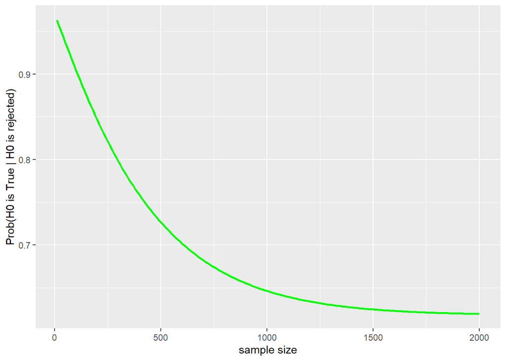

```r
#(i)
ggplot(df, aes(x = N, y = h0_true_geiven_rejected)) +
    geom_line(color = "green", size = 1) +
    xlab("sample size") +
    ylab("Prob(H0 is True | H0 is rejected)")
```

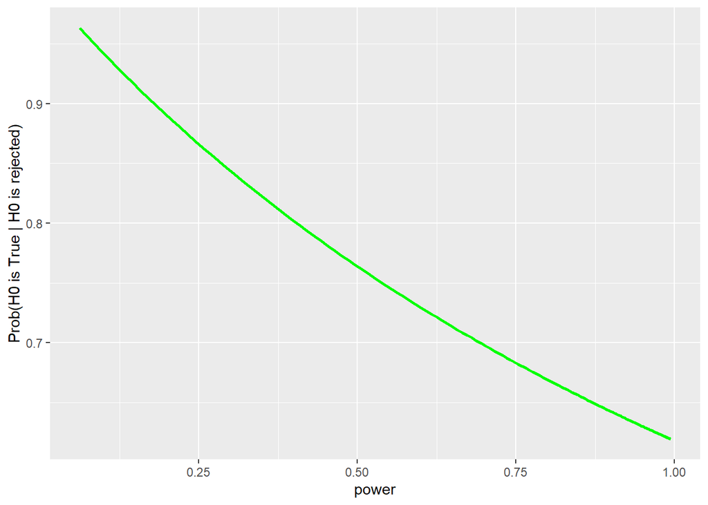

```r
#(ii)
ggplot(df, aes(x = power, y = h0_true_geiven_rejected)) +
    geom_line(color = "green", size = 1) +
    xlab("power") +
    ylab("Prob(H0 is True | H0 is rejected)")
```

(5) 本題請你跳脫假設檢定的框架。你能單從原始的資訊，直接計算 x = 0 的機率嗎？亦即，請你計算 $\text{Prob}(x = 0 | y = 2.2, N = 100).$

提示：用常態分配的機率密度。

#### Answer:

記常態分配 $N(\mu, \sigma^2)$ 在 $y$ 的機率密度為 $p(\mu, \sigma^2, y)$. 則

$$\begin{align*}
\mathbb{P}(x = 0 | y = 2.2, N = 100)
& = \frac{\mathbb{P}(x = 0, y = 2.2, N = 100)}
{\mathbb{P}(y = 2.2, N = 100)}
= \frac{\mathbb{P}(x = 0, y = 2.2, N = 100)}
{\mathbb{P}(x = 0, y = 2.2, N = 100) +
\mathbb{P}(x = 1, y = 2.2, N = 100)} \\
& = \frac{\mathbb{P}(y = 2.2 | x = 0, N = 100) \cdot \mathbb{P}(x =
0, N = 100)}
{\mathbb{P}(y = 2.2 | x = 0, N = 100) \cdot \mathbb{P}(x = 0, N = 100)
+
\mathbb{P}(y = 2.2 | x = 1, N = 100) \cdot \mathbb{P}(x = 1, N =
100)} \\
& = \frac{p(0, 1, 2.2) \times 0.97}{p(0, 1, 2.2) \times 0.97 + p(1,
1, 2.2) \times 0.03}
= \frac{\exp(-\frac{2.2^2}{2}) \times 0.97}{\exp(-\frac{2.2^2}{2})
\times 0.97 + \exp(-\frac{1.2^2}{2}) \times 0.03}
\simeq 0.8552.
\end{align*}$$